# REGRESSION MODEL EVALUATION

## EVALUACIÓN MODELO DE REGRESIÓN

LOS MODELOS DE REGRESIÓN LINEAL, DEBEN DE CUMPLIR UNA SERIE DE SUPUESTOS PARA QUE SEAN BUENOS Y FIABLES, COMO:

**linealidad:** El modelo asume que hay una relación lineal entre las variables independientes y la variable dependiente.

**Independencia de los errores:** Los residuos deben ser independientes entre sí, es decir, no debe haber autocorrelación (especialmente importante en series temporales).

**Homocedasticidad:** La varianza de los errores debe ser constante en todo el rango de valores de la variable dependiente. En otras palabras, los residuos no deben mostrar patrones sistemáticos y deben tener una dispersión uniforme.

**Distribución normal de los residuos:** Los residuos deben seguir una distribución normal. Esto es especialmente importante para la validez de los intervalos de confianza y los tests de hipótesis.

**No Multicolinealidad:** Las variables independientes no deben estar fuertemente correlacionadas entre sí, ya que esto puede distorsionar las estimaciones de los coeficientes y dificultar la interpretación del modelo. Recalcar lo de FUERTEMENTE correlacionadas entre si.

VAMOS A IR COMPROBANDO CADA UNO DE ESTOS SUPUESTOS PARA VER LA FIABILIDAD DE ESTE MODELO.

LINEALIDAD Y HOMOCEDASTICIDAD

PARA ELLO, HAREMOS UN GRÁFICO DE RESIDUOS VS AJUSTADOS. AUNQUE EN REALIDAD YA HAYAMOS VISTO EN LOS GRÁFICOS DE DISPERSIÓN QUE HAY UNA CLARA LINEALIDAD ENTRE LAS VARIABLES NUMERICAS Y LA VARIABLE TARGET, ESTA PRUEBA ES DE FUEGO PARA LA LINEALIDAD Y HOMOCEDASTICIDAD.

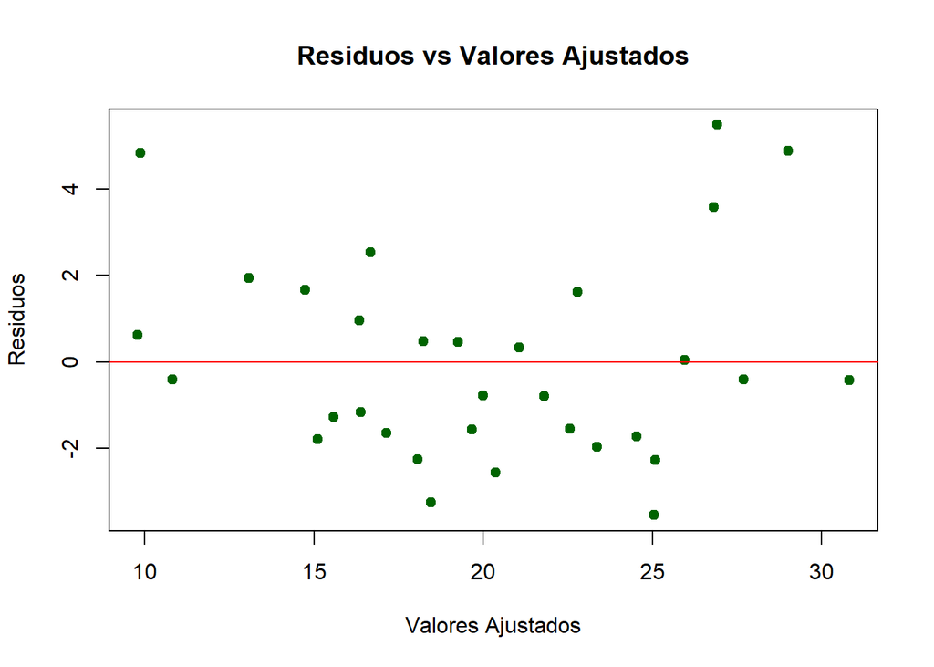

```r
# Linealidad

# Gráfico de residuos vs valores ajustados
plot(modelo_final$fitted.values, modelo_final$residuals,
     main = "Residuos vs Valores Ajustados",
     xlab = "Valores Ajustados",
     ylab = "Residuos",
     pch = 19, col = "darkgreen")
abline(h = 0, col = "red")  # Línea horizontal en 0
```

PARA INTERPRETAR ESTE GRÁFICO, TENEMOS QUE VER COMO SE DISPONEN LOS PUNTOS VERDES. SI ESTOS FORMAN ALGÚN PATRON SOBRE LA LINEA ROJA (COMO UNA U), PODRIA INDICAR QUE LA RELACIÓN NO ES LINEAL Y HETEROCEDASTICIDAD. SIN EMBARGO, VEMOS QUE NO HAY PATRÓN Y QUE LOS RESIDUOS SE DISPONEN DE FORMA ALEATORIA, POR LO QUE EL SUPUESTO DE LINEALIDAD Y HOMOCEDASTICIDAD, SE CUMPLEN.

INDEPENDENCIA DE LOS ERRORES

PARA ESTE SUPUESTO, HACEMOS EL TEST DE DURBIN WATSON

```r
# test de Durbin Watson
dwtest(modelo_final)
```

```
    Durbin-Watson test

data:  modelo_final
DW = 1.8924, p-value = 0.2644
alternative hypothesis: true autocorrelation is greater than 0
```

ESTE TEST MIDE LA INDEPENDENCIA DE LOS RESIDUOS. SI EL TEST DA UN VALOR CERCANO A 2, SON INDEPENDIENTES. ESTE ES EL CASO DE NUESTRO MODELO, POR LO QUE SE CUMPLE EL SUPUESTO DE INDEPENDENCIA.

NORMALIDAD

PARA EL SUPUESTO DE NORMALIDAD, PODEMOS USAR UN GRÁFICO Q-Q DE LOS RESIDUOS O UN TEST SHAPIRO-WILK PARA ELLO. HAGAMOS LOS DOS

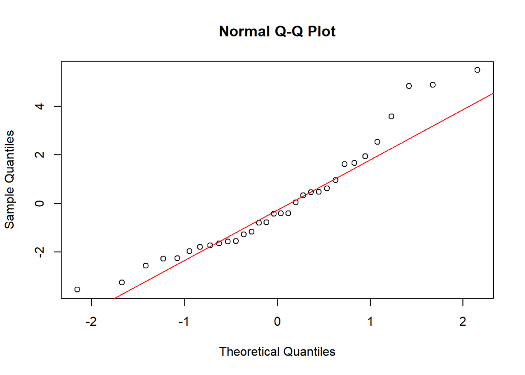

```r
# Gráfico Q-Q
qqnorm(modelo_final$residuals)
qqline(modelo_final$residuals, col = "red")
```

```r
# Shapiro-Wilk test
shapiro.test(modelo_final$residuals)
```

```
    Shapiro-Wilk normality test

data:  modelo_final$residuals
W = 0.93022, p-value = 0.03971
```

PARA INTERPRETAR EL GRÁFICO Q-Q, SOLO TENEMOS QUE FIJARNOS EN SI LOS PUNTOS SIGUEN LA LINEA. EN ESTE CASO, POR NORMAL GENERAL LOS SIGUEN SALVO CIERTOS PUNTOS EN LA PARTE DE ARRIBA. ESTOS PODRÍAN TRATARSE DE OUTLIERS Y HABRÍA QUE VER COMO SE TRATAN.

POR OTRO LADO, EL TEST DE SHAPIRO-WILK, ES UN SIMPLE TEST QUE NOS DICE SI LA DISTRIBUCIÓN, EN ESTE CASO DE LOS RESIDUOS, ES NORMAL O NO. SI EL P-VALOR ES <0.05 PODRIAMOS ESTAR ANTE UNA DISTRIBUCIÓN NO NORMAL. EN ESTE CASO, EL P-VALOR ES DE 0.03971, POR LO QUE SE RECHAZA ESTE SUPUESTO. NO OBSTANTE, ESTE SUPUESTO ES RECHAZADO, JUNTO CON UN GRAFICO Q-Q UN TANTO PECULIAR, DEBIDO A LOS POSIBLES OUTLIERS QUE HAY. ES POR ESO QUE DEBERIAMOS PLANTEARNOS EL QUITARLOS PARA VER SI NUESTRO MODELO MEJORA. SE DEJA COMO COLABORACIÓN PARA QUIEN LO QUIERA!

MULTICOLINEALIDAD

PARA LA MULTICOLINEALIDAD, USAREMOS DE INDICE DE DE VARIANZA DE LA INFLACIÓN (VIF), de la libreria car

```r
library(car)
vif(modelo_final)
```

```
     disp        hp      drat        wt      qsec      carb
18.954687  8.956570  2.510706 14.204683  4.650604  6.308884
```

SI EL VIF ES MAYOR A 10, HAY MULTICOLINEALIDAD, CONFORME MÁS SE ACERQUE A 1, MENOR SERÁ. PODEMOS OBSERVAR COMO DOS DE LAS VARIABLES, **disp** y **wt** TIENEN UN VIF MAYOR A 10. ESTO JUNTO A LOS OUTLIERS PODRIAN HACERNOS LLEGAR A LA CONCLUSIÓN DE QUE SON LOS CAUSANTES DE QUE ESTE MODELO LINEAL NO SEA EL MEJOR. ¿ESTO QUIERE DECIR QUE TODO EL TRABAJO QUE HEMOS HECHO HASTA AHORA NO SIRVA DE NADA? ROTUNDAMENTE NO. ESTO NOS SIRVE PRECISAMENTE PARA VER QUE VARIABLES O TRATAMIENTOS DE VALORES DEBEMOS HACER PARA CONSTRUIR UN MODELO QUE DE VERDAD EXPLIQUE BIEN LA VARIABLE TARGET Y QUE TENGA UN R^2 ACEPTABLE.

CREO QUE ES UNA BUENA CONCLUSIÓN PARA DEJAR EL PROYECTO AQUI. ME GUSTARIA QUE TODO AQUEL QUE LEA ESTO, INTENTARA HACER LOS CAMBIOS QUE CONSIDERE OPORTUNOS Y ME HAGA FEEDBACK CON SUS PROPIOS ANÁLISIS. GRACIAS!